# Prediction in Sentiment Analysis - Amazon Sample

Final Report

Philippe Lambot

April 14, 2020

## *********************************************************************************

## PREDICTION IN SENTIMENT ANALYSIS - AMAZON SAMPLE

## *********************************************************************************

## EXECUTIVE SUMMARY

In this project, **sentiment analysis** has been conducted on an Amazon sample provided in UCI Machine Learning Repository. Predictive accuracy of 88 % has been reached on the validation set, against 50 % with the baseline method.

Second, **text mining** has brought additional accuracy improvement with 10 percentage points. Two insights have been determinant: in decision trees, tokens conveying subjective information predominate; but other pieces of subjective information are not used in numerous false negatives and false positives. Such ignored subjective information has been retrieved from random samples of false negatives and false positives, exclusively on the training set; customized lists have been established with tokens having either positive or negative sentiment orientation; occurrences of these tokens in reviews have been replaced either with a positive or a negative generic token.

Third, **machine learning optimization** has been performed across 10 models and has boosted accuracy with 4 additional percentage points. Testing has been conducted on accuracy distributions across bootstrapped resamples. eXtreme Gradient Boosting has emerged as the most performing model in this project.

### TAGS

sentiment analysis, natural language processing, text mining, subjective information, tokenization, bag of words, word frequency, wordclouds, decision trees, false negatives, false positives, text classification, polarization, lists of positive n-grams, lists of negative n-grams, text substitution, machine learning, binary classification, eXtreme Gradient Boosting, Monotone Multi-Layer Perceptron Neural Network, Random Forest, Stochastic Gradient Boosting, Support Vector Machines with Radial Basis Function Kernel, AdaBoost Classification Trees, bootstrapping, accuracy distributions across resamples, R

### GITHUB

https://github.com/Dev-P-L/Sentiment-Analysis

## FOREWORD TO READERS

Dear Readers, you are most welcome to run the project on your own computer if you so wish.

This project is lodged with the GitHub repository https://github.com/Dev-P-L/Sentiment-Analysis.

It is comprised of twelve files. All code is included in Sentiment_Analysis.Rmd. It does not show in the final HTML report, called Sentiment_Analysis_Final_Report.html.

For your convenience, the dataset has already been downloaded onto my GitHub repository wherefrom it will be automatically retrieved by the code from Sentiment_Analysis.Rmd. If you so wish, you can also easily retrieve the dataset from https://archive.ics.uci.edu/ml/datasets/Sentiment+Labelled+Sentences and adapt the Sentiment_Analysis.Rmd code accordingly.

You can knit Sentiment_Analysis.Rmd (please in HTML) and produce Sentiment_Analysis_Final_Report.html on your own computer. On my laptop, running Sentiment_Analysis.Rmd takes approximately six hours. For information, here are some characteristics of my work environment:

- R version 3.5.1 (2018-07-02) – “Feather Spray”,
- RStudio Version 1.1.456,
- Windows 10.

Some packages are required in Sentiment_Analysis.Rmd. The code from Sentiment_Analysis.Rmd contains instructions to download these packages if they are not available yet.

Let’s get in touch with data.

## I. GETTING IN TOUCH WITH DATA

As explained on the UCI website, data is organized in a CSV file in two columns. In the first column, there are 1,000 Amazon product reviews (sentences). In the second column, there is a positive or negative evaluation; the ratio of positive evaluations is 50 %.

That file will be split into training reviews - two thirds of reviews - and validation reviews. Let’s have a quick look at a few training reviews.

```
## 'data.frame':    12 obs. of  3 variables:
##  $ ro       : chr  "61" "187" "188" "218" ...
##  $ text     : chr  "Essentially you can forget Microsoft's tech support." "Design Flaw?." "Great phone!." "I also didn't like the \"on\" button, it felt like it would crack with use." ...
##  $ sentiment: Factor w/ 2 levels " Pos","Neg": 2 2 1 2 1 1 1 2 2 1 ...
```

|  | TRAINING REVIEW | SENTIMENT |
| --- | --- | --- |
| 61 | Essentially you can forget Microsoft’s tech support. | Neg |
| 187 | Design Flaw?. | Neg |
| 188 | Great phone!. | Pos |
| 218 | I also didn’t like the “on” button, it felt like it would crack with use. | Neg |
| 247 | Excellent wallet type phone case. | Pos |
| 344 | New Battery works great in phone. | Pos |
| 523 | I ended up sliding it on the edge of my pants or back pockets instead. | Pos |
| 640 | Disappointing accessory from a good manufacturer. | Neg |
| 675 | Then I had to continue pairing it periodically since it somehow kept dropping. | Neg |
| 874 | My sister has one also and she loves it. | Pos |
| 893 | Excellent product for the price. | Pos |
| 970 | I’m trying to return it for a refund. | Neg |

After shaking hands with data, let’s proceed to some NLP.

## II. NATURAL LANGUAGE PROCESSING

### A. Corpus - Tokenization - Bag of Words

After being downloaded, data will be transposed into a corpus. Then it will be processed in NLP: words will be lowercased, punctuation marks will be removed as well as stopwords and finally words will be stemmed.

Tokenization will then take place, a bag of words being created. Applying a sparsity threshold will only leave tokens that appear in at least 0.5 % of reviews. The bag of words takes the form of a Document Term Matrix, where the 1,000 rows correspond to the 1,000 reviews and there is a column for each token selected across the sparsity process. At the junction of each row and each column, there is a frequency number representing the number of occurrences of the corresponding token in the corresponding review.

As a pre-attentive insight, a wordcloud will show the most frequent tokens.

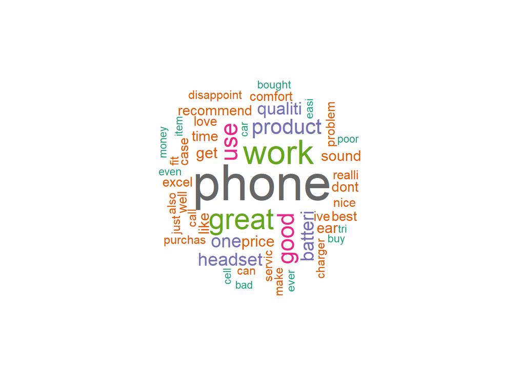

There are topic-related tokens such as “phone”, tokens conveying subjective information such as “great”, etc. Before analyzing token categories, let’s check up the adequacy of results.

### B. Checking up NLP Output

Some tokens were not expected, such as “dont” or “ive”, since they seem to originate in short forms and were expected to have been eliminated as stopwords. Let’s start investigating with “dont”. How many rows contain " dont “?

|  | OCCURRENCE OF “dont” |
| --- | --- |
| Bag of Words | 17 |

Let’s have a look at the first review that has produced “dont”.

|  | FIRST REVIEW GENERATING “dont” |
| --- | --- |
| Training Set | Dont waste your money… |

“dont” contains a spelling error or is “alternative” grammar. Nevertheless, ideally, it should be treated as a short form from standard grammar, i.e. as the short form “don’t”. Consequently, if we want to eradicate short forms, we’ll have to complement stopwords with variants such as “dont”, “couldnt”. This will be done.

Let’s see the second review that, after NLP, has generated “dont”.

|  | SECOND REVIEW GENERATING “dont” |
| --- | --- |
| Training Set | That’s a huge design flaw (unless I’m not using it correctly, which I don’t think is the case). |

This is another scenario: “don’t” has been written in a standard way, but all punctuation marks have been removed, consequently it has become “dont” and is no longer identical to the stopword “don’t” and, very logically, has not been removed. Consequently, stopwords containing apostrophes should be removed before removing punctuation. Or punctuation marks should be removed except for apostrophes and hyphens: this solution will be applied because it meets the objective and allows to immediately get rid of all other marks of punctuation.

After examining all tokens coming from training reviews, other oddities have been discovered. There are several unigrams that seem to originate from bigrams, e.g. “brokeni” at row 24.

| 24 | broke | broken | brokeni | brows | browser |
| --- | --- | --- | --- | --- | --- |

Where does “brokeni” come from?

|  | REVIEW PRODUCING “brokeni” |
| --- | --- |
| Training Set | I got the car charger and not even after a week the charger was broken…I went to plug it in and it started smoking. |

What happened? Well, “broken…I” was first lowercased to “broken…i”, then punctuation was removed by the function removePunctuation(), which does not insert any white space character, and “broken…i” has become “brokeni”.

In further text mining and machine learning steps, “brokeni” would be treated differently than “broken”, which can be seen on the same row, i.e. on row 24 of the tokens from training reviews. This has to be changed.

### C. Fine Tuning NLP

Instead of the function removePunctuation() from the package tm, specific for loops will be developed, preprocessing reviews according to the needs stated above:

- punctuation marks other than apostrophes will be replaced with white space characters instead of just being removed;
- short forms will then be removed and afterwards remaining apostrophes will also be replaced with white space characters.

Moreover, among stopwords, short forms (contractions) need to be specifically treated. Additional needs of breakdown might also emerge. Consequently, stopwords will be split. Starting from the list delivered by the function stopwords(“english”) from the package tm, four CSV files will be produced.

These are the four files: - short_forms_pos.csv, with all positive short forms from stopwords(“english”) such as “she’s”, a few additional ones and numerous misspelled variants such as “she s” or “shes”; - short_forms_neg.csv, in the same approach, for short forms such as “isn’t”, “daren’t” but also “isn t”, “isnt”, etc.; - negation.csv, with seven negational unigrams such as “not” or “no”; - stopwords_remaining.csv, which is self-explanatory.

The 4 files have been uploaded to the GitHub repository https://github.com/Dev-P-L/Sentiment-Analysis. They are going to be downloaded now and integrated into NLP pre-processing.

Let’s rebuild the corpus, the bag of words and the wordcloud.

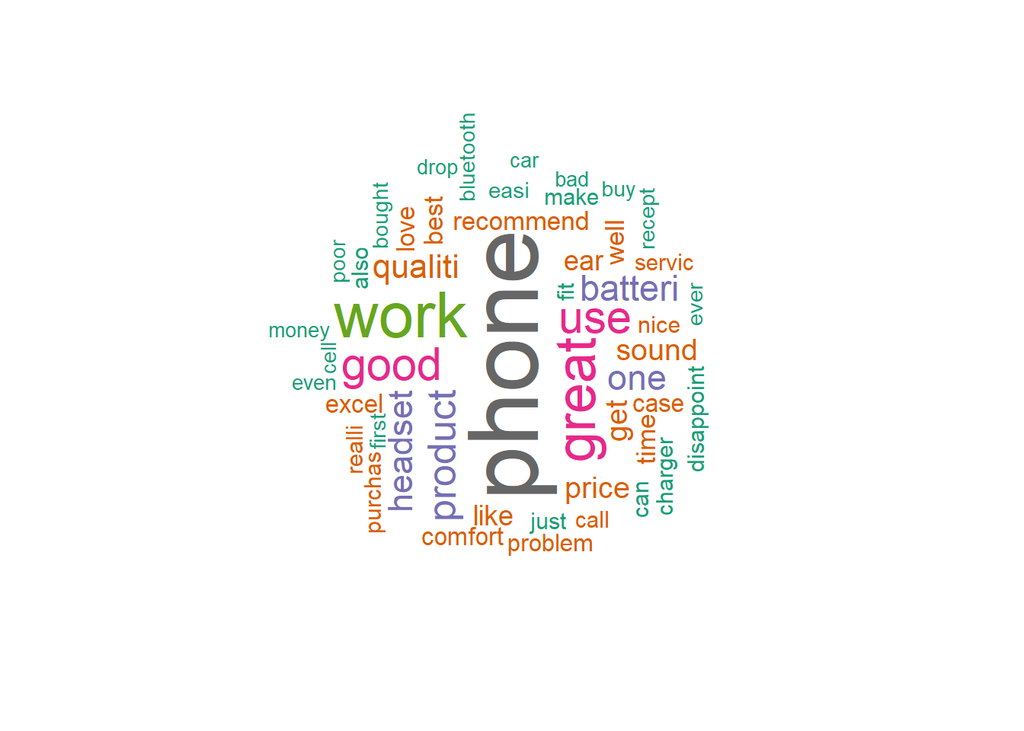

In the wordcloud, there is no more token originating from short forms. Let’s have a broader look, building up a presentation table and checking whether abovementioned oddities have disappeared. Let’s check up in the bag of words whether “dont” has indeed disappeared.

| 50 | divis | dna | dock | dollar | done |
| --- | --- | --- | --- | --- | --- |

So has “ive”!

| 96 | issu | item | jabra | jack | jawbon |
| --- | --- | --- | --- | --- | --- |

The same again for “brokeni”.

| 21 | break | breakag | broke | broken | brows |
| --- | --- | --- | --- | --- | --- |

As well as many other oddities. I leave uncorrected some spelling errors, such as “disapoint” or “dissapoint”, because this is no repetitive structure and occurrence seems marginal.

Let’s have a first try at predicting sentiment on the basis of sentSparse_av0, which is our training set.

### D. Measuring NLP Impact on Machine Learning Accuracy

The chosen machine learning model will be CART: it runs rather quickly and delivers clear decision trees. Running function rpart() on the training set delivers the accuracy level mentioned hereunder.

|  | ACCURACY ON THE TRAINING SET |
| --- | --- |
| Model: CART | 0.7784 |

Now let’s train the rpart method with the train() function from the caret package.

By default, the train() function would train across 3 values of cp (the complexity parameter) and 25 bootstrapped resamples for each tuned value of cp.

The default resampling method is bootstrapping, samples being built with replacement, some reviews being picked up twice or more and some other reviews not being selected. This method seems especially appropriate here because the size of each resample will be the same of the size of the training set, which is already limited, i.e. 668. Working with e.g. k-fold cross-validation would imply further splitting the training set.

As far as the number of tuned values is concerned, let’s upgrade it to 15 to increase the odds of improving accuracy, especially as rpart runs rather quickly. Will accuracy improve?

|  | ACCURACY ON THE TRAINING SET |
| --- | --- |
| Model: CART + cp Tuning | 0.7859 |

Accuracy increases somewhat. For the record, let’s have a look at a graph showing how accuracy evolves across the 15 cp values chosen by the train() function.

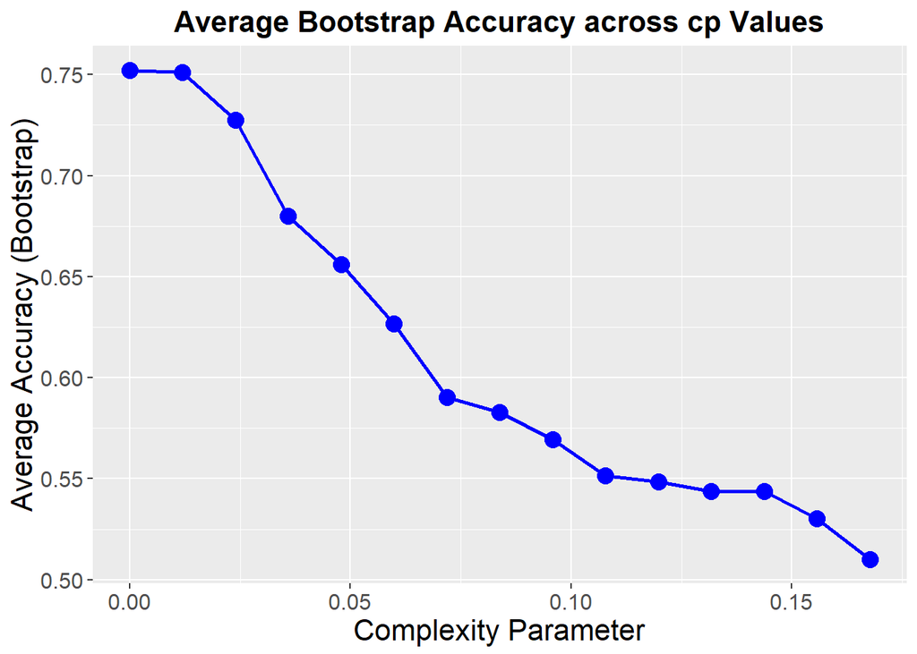

On the graph above, maximum accuracy is a bit lower than the level previously indicated. Why is it different? Because on the graph it is, for each cp value, the average accuracy on the 25 bootstrapped resamples while accuracy previously given related to the whole training set.

The optimal value of cp is near zero. Is it really zero?

|  | OPTIMAL cp VALUE |
| --- | --- |
| Model: CART + cp Tuning | 0.0000 |

Yes, it is zero. This means that the train() function has kept the decision tree as complex as possible by assigning a zero value to the complexity parameter.

On the whole training set, the rpart model without tuning delivers 78 % accuracy and the rpart model with tuning gives 79 %. Both levels are substantially higher than accuracy provided by the baseline model. The baseline model would predict a positive evaluation for all reviews (or alternatively a negative evaluation for all reviews) since prevlence is 50 %. What accuracy level would the baseline model deliver?

|  | ACCURACY ON THE TRAINING SET |
| --- | --- |
| Model: Baseline | 0.5000 |

Let’s summarize results from the three models, not only with accuracy but also with additional performance metrics.

| MODEL ID | SHORT DESCRIPTION | ACCURACY | SENSITIVITY | NEG PRED VAL | SPECIFICITY | POS PRED VAL |
| --- | --- | --- | --- | --- | --- | --- |
| baseline | baseline model | 0.5000 | 1.0000 | Div. by 0 | 0.0000 | 0.5000 |
| cart_av0 | CART | 0.7784 | 0.6617 | 0.7257 | 0.8952 | 0.8633 |
| cart_tuned_av0 | CART + tuning | 0.7859 | 0.7126 | 0.7493 | 0.8593 | 0.8351 |

In the table above, on row 1, fonts have been stricken through to indicate that this model is discarded because if delivers only 50 % accuracy and looks like a dead-end path.

The other two models should be seen as a cumulative process bringing accuracy improvement in a stepwise and incremental way, with the one on green background being the best in accuracy. Models 2 and 3 deliver higher accuracy but aslo asymetry between other performance metrics: sensitivity and negative predictive value are lower than specificity and positive predictive value. This reflects false negatives being more numerous than false positives. False negatives are predictions pointing to “Neg” while the reference value is " Pos“. This is an insight for text mining: perusing false negatives and coming with actionable insights.

In order to confirm that false negatives are more numerous than false positives, let’s have a look at the confusion matrix for both models. First, the confusion matrix from the rpart model without tuning.

|  | Actually positive | Actually negative |
| --- | --- | --- |
| Predicted positive with CART | TP = 221 | FP = 35 |
| Predicted negative with CART | FN = 113 | TN = 299 |

The weak point lies in the first column, on green background: the relatively high number of false negatives and, as a corollary, the relatively low number of true positives. On the reference positive class (" Pos" in label), predicting seems problematic or at the very least challenging: false negatives are rife. On the contrary, on the reference negative class (“Neg” in label), predicting has run smoothly, with a satisfactorily low number of false positives.

The tuned rpart model is expected to slightly reduce the excess in false negatives.

|  | Actually positive | Actually negative |
| --- | --- | --- |
| Predicted positive with CART + tuning | TP = 238 | FP = 47 |
| Predicted negative with CART + tuning | FN = 96 | TN = 287 |

With the tuned rpart model, accuracy has slightly improved: the sum of numbers on the main diagonal is larger.

On the green background, predicting on the reference positive class is less prolific in false negatives and, as a corollary, true positives are more predominant. On the secondary diagonal, imbalance between false negatives and false positives is less marked, not only because there are less false negatives but also because there are more false positives. Nevertheless false negatives remain the weak point, still being twice as numerous as false positives.

False negatives - and false positives - will be perused through text mining in the next section, looking for new insights towards accuracy improvement.

## III. TEXT MINING TOWARDS HIGHER ACCURACY

Let’s now have a look at the false negatives from the CART model with tuning, which constitute a challenge.

### A. Visualizing False Negatives from CART with Tuning

|  | Review Corresponding to a FALSE NEGATIVE with CART + Tuning | After NLP | Usable Subjective Information |
| --- | --- | --- | --- |
| 1 | The phone loads super! | phone load super | super |
| 2 | This phone is very fast with sending any kind of messages and web browsing is significantly faster than previous phones i have used. | phone fast send kind messag web brows signific faster previous phone use | fast + faster |
| 3 | The color is even prettier than I thought it would be, and the graphics are incredibly sharp. | color even prettier thought graphic incred sharp | prettier + sharp |
| 4 | I’m still infatuated with this phone. | still infatu phone | infatu |
| 5 | Now I know that I made a wise decision. | now know made wise decis | wise |
| 6 | Jawbone Era is awesome too! | jawbon era awesom | awesom |
| 7 | Virgin Wireless rocks and so does this cheap little phone! | virgin wireless rock cheap littl phone | rock |
| 8 | I’ve had no trouble accessing the Internet, downloading ringtones or performing any of the functions. | troubl access internet download rington perform function | [no trouble] |
| 9 | Their Research and Development division obviously knows what they’re doing. | research develop divis obvious know | [knows what they’re doing] |
| 10 | Product is exactly as described. | product exact describ | [as described] |
| 11 | It seems completely secure, both holding on to my belt, and keeping the iPhone inside. | seem complet secur hold belt keep iphon insid | secur |
| 12 | Seller shipped quickly and much cheaper than the competitors. | seller ship quick much cheaper competitor | quick |

There are three scenarios, each illustrated on a different background color. Let’s get started with the first scenario on the blue background.

### B. Subjective Information Unigrams

On the blue background in the table above, there 9 cases out of 12. In each of these 9 reviews, there is at least one token with subjective information that is clear from a human point of view. Let’s just pinpoint “super”, “fast”, “faster”, “prettier”, “infatuated”, “wise”, “awesome”, “rocks”, etc., or, after stemming “super”, “fast”, “faster”, “prettier”, “infatu”, “wise”, “awesom”, “rock”, etc.

These words, and the related standardized tokens, can be classified in two categories:

- compliance-related tokens, expressing compliance or incompliance with expectations, requirements or advertisements (“fast”, “faster”, “rocks”, etc.),
- sentiment-related tokens other than in previous category (“infatuated”).

The difference between the two categories can sometimes be tricky and both categories will be referred to altogether in this project using phrases such as “subjective information” or “tokens conveying subjective information”.

“Unfortunately”, the tokens pinpointed among the false negatives do not show in the decision trees. Let’s visualize the decision tree from the CART model with tuning.

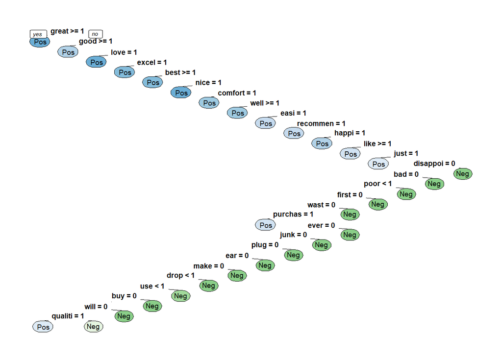

What types of tokens can be seen in the decision tree? There is a majority of tokens conveying subjective information (“great”, “comfort”, “love”, “like”, disappoi“, etc.). They are usually the highest ranked. There are other types of tokens: - intent-related tokens (”purchas“,”buy“) or - topic-related tokens (”plug“,”ear“).

Which is an interesting insight. In CART, tokens conveying subjective information predominate, which is not at all surprising! This points to solutions allocating higher priority to tokens conveying subjective information.

Although the majority of tokens are conveying subjective information in the decision tree, many tokens with subjective information are present among false negatives but do not show in the decision tree. It is probably a matter of word (or token) frequency. This can be first checked up in the wordcloud that has already been visualized.

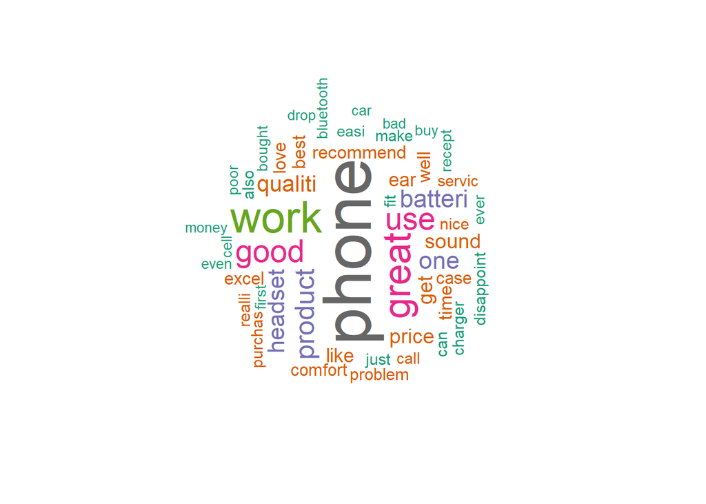

The wordcloud, which requires a minimal frequency of 10, is not comprised of the tokens with subjective information pinpointed among the false negatives.

Among tokens depicted in the wordcloud, there are - topic-related tokens (“phone”, “batteri”, “headset”, “sound”, “ear”, etc.), - intent-related tokens (“purchas”, “buy”, “bought”), - compliance-related tokens, expressing compliance or incompliance with expectations, requirements or advertisements (“fit”, “comfort”, “problem”, etc.), - sentiment-related tokens other than in previous category (“love”, “like”, etc.).

“phone”, which is topic-related, is the token with the highest frequency. Other topic-related tokens rank among the highest frequencies: “batteri”, “product”, “headset”, “sound”, etc. “phone” has the highest frequency in the wordcloud but does not show in the decision tree. The same holds for other highly ranked topic-related tokens.

This looks like an interesting insight. Token frequency should not be the only criterion. Actually, there should be some hierarchy between types of tokens (subjective information, intent-related, topic-related). This does not necessarily mean a strict hierarchy starting with types and then going down to tokens; there could be some intermixture, token frequency could coexist with prioritization of subjective information.

For illustrative purposes, tokens can be visualized in decreasing order of frequency in the graph below.

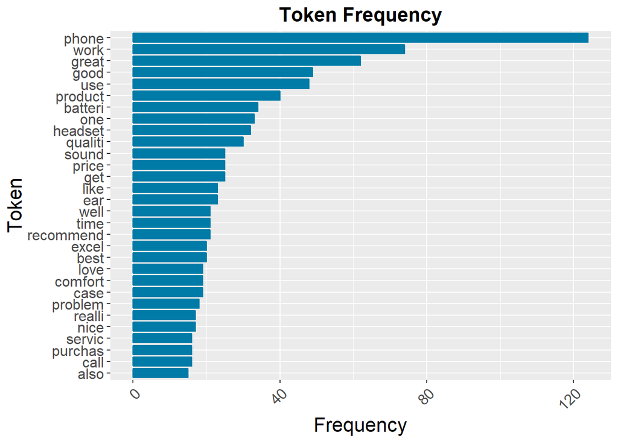

In conclusion, it might be impactful to garner subjective information conveyed by tokens such as “super”, “faster”, “prettier”, “infatu”, “awesom”, etc. Since CART doesn’t do it, why not replace such tokens with a generic token either positive or negative? This would impower subjective information by building high frequency generic tokens only typified by sentiment orientation.

In this project, polarity of some tokens conveying subjective information will be inserted in additional files. That is one avenue of improvement.

### C. Negation Handling

Let’s go back to the table above that is comprised of 12 reviews corresponding to false negatives in the model cart_tuned. More particularly, let’s retrieve the review with a negational unigram.

|  |  | Review Corresponding to a FALSE NEGATIVE with CART + Tuning | After NLP | Usable Subjective Information |
| --- | --- | --- | --- | --- |
| 8 | 8 | I’ve had no trouble accessing the Internet, downloading ringtones or performing any of the functions. | troubl access internet download rington perform function | [no trouble] |

The bigram “no trouble” is clear from a human point of view but this bigram has become “troubl”, the negational token “no” having been removed with all other stopwords. Even if “troubl” is polarized under a generic negative token, as suggested above, the right polarity of “no trouble” doesn’t show. Two avenues are opened up: the whole bigram “no trouble” could be converted into a generic token with postive orientation or, more generally, negational stopwords such as “not” or “no” could no longer be removed, which is another avenue for improvement.

In this sample, there is only one case out of 12 with an ignored negational phrase. Is it worthwhile heading for properly dealing with negational unigrams? Let’s integrate negational unigrams into the bag of words and produce a wordcloud in order to get some pre-attentive insight about frequency of negational unigrams such as “not” or “no”.

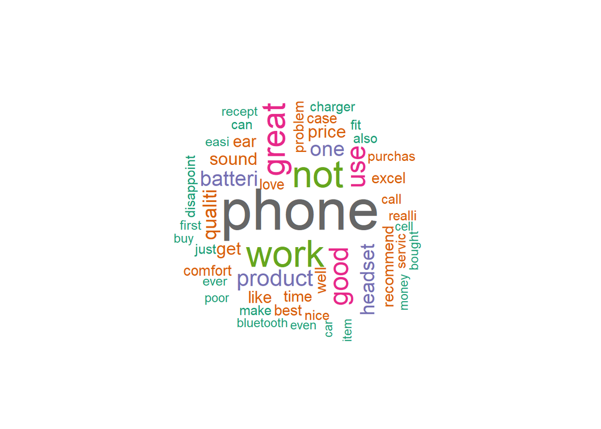

Would one negational unigrams appear in a wordcloud? “not” is indeed highly ranked, just below “phone”. This is an insight advocating inclusion of negational unigrams.

Let’s have a look at word associations with “not”: does it often change polarity of review?

| Token | Correlation with “not” |
| --- | --- |
| impress | 0.21 |
| compani | 0.15 |
| enough | 0.14 |
| plug | 0.14 |
| motorola | 0.13 |
| unit | 0.13 |
| will | 0.13 |
| charger | 0.12 |
| item | 0.12 |
| broke | 0.11 |
| connect | 0.10 |
| charg | 0.09 |
| contact | 0.09 |
| player | 0.09 |
| drop | 0.08 |
| minut | 0.08 |
| problem | 0.08 |
| replac | 0.08 |
| sinc | 0.08 |
| went | 0.08 |
| design | 0.07 |
| work | 0.07 |
| car | 0.06 |
| never | 0.06 |
| new | 0.06 |
| start | 0.06 |
| tri | 0.06 |
| cell | 0.05 |
| wear | 0.05 |

On the list, the first stemmed unigram associated with “not” is “impress”. Let’s localize the reviews producing “impress” to get an idea of frequency and of decisiveness about polarity.

|  | Training Review Containing “impressed” |
| --- | --- |
| 1 | He was very impressed when going from the original battery to the extended battery. |
| 2 | Not impressed. |
| 3 | great headset, very impressed - H500. |
| 4 | I am very impressed with this headset from Plantronics. |
| 5 | I am not impressed with this and i would not recommend this item to anyone. |
| 6 | All it took was one drop from about 6 inches above the kitchen counter and it was cracked.I am not impressed and I am not laughing. |

In the three training reviews on green background, negation unigrams completely change polarity of review. Among the training reviews, there are three reviews containing “not impressed”. Moreover, in the second of these reviews, there is also “not recommend” and “not laughing”. This illustrates the usefulness of including negational words in one way or another.

Up to now, negation has been shown in negational unigrams but negation can also be encapsulated into short forms (also called “contractions”). This sample of false negatives, which has been selected at random, is not comprised of negative short forms. But the same procedure, applied to false positives, delivers several of them.

|  | Review Corresponding to a FALSE POSITIVE with CART + Tuning | After NLP | Usable Subjective Information |
| --- | --- | --- | --- |
| 1 | Not a good bargain. | good bargain | not a good |
| 2 | All I can do is whine on the Internet, so here it goes.The more I use the thing the less I like it. | can whine internet goe use thing less like | whine + ? the less |
| 3 | I still maintain that monkeys shouldn’t make headphones, we just obviously don’t share enough DNA to copy the design over to humans. | still maintain monkey make headphon just obvious share enough dna copi design human | shouldn’t |
| 4 | I put the latest OS on it (v1.15g), and it now likes to slow to a crawl and lock up every once in a while. | put latest os v g now like slow crawl lock everi | slow + crawl + lock-up |
| 5 | The plug did not work very well. | plug work well | did not work well |
| 6 | Still Waiting…… I’m sure this item would work well.. if I ever recieve it! | still wait sure item work well ever reciev | still waiting |
| 7 | My experience was terrible….. This was my fourth bluetooth headset, and while it was much more comfortable than my last Jabra (which I HATED!!! | experi terribl fourth bluetooth headset much comfort last jabra hate | terrible |
| 8 | Also difficult to put on.I’d recommend avoiding this product. | also difficult put recommend avoid product | difficult |
| 9 | I only used it two days, and it wasn’t always easy to hear with. | use two day alway easi hear | wasn’t always easy |
| 10 | I am sorry I made this purchase. | sorri made purchas | sorry |
| 11 | Not as good as I had hoped. | good hope | not as good |
| 12 | I don’t like this Nokia either. | like nokia either | don’t like |

In six cases, there is negation, which machine learning could not take into account since these negation forms had been removed through NLP. There are four negative short forms.

This shows the importance of negation, be it under the form of negational unigrams (“no”, etc.) or under the form of negational short forms.

For the record, in the bale of false positives, blue background has been used where at least one token per review expresses sentiment orientation, from a human point of view: “difficult” or “sorry”. This again shows the interest of replacing ignored subjective information tokens with one generic tokens expressing either negative (here) or positive sentiment.

Green background has been used in simple negation scenarios: there is negation and at least one unigram conveying positive subjective information.

Gray background has been used for more complex cases, with e.g. sarcasm: these cases will be analyzed in the next section.

### D. Multigrams Conveying Subjective Information

Sentiment can also be expressed through associations of words beyond cases of negation already treated.

In some cases, these are rather stereotyped phrases. False negatives have provided two examples: “knows what they’re doing” (competency statement) or “as described” (compliance statement). Some of these phrases will be listed among positive multigrams and replaced with a generic token with positive orientation.

|  |  | Review Corresponding to a FALSE NEGATIVE with CART + Tuning | After NLP | Usable Subjective Information |
| --- | --- | --- | --- | --- |
| 9 | 9 | Their Research and Development division obviously knows what they’re doing. | research develop divis obvious know | [knows what they’re doing] |
| 10 | 10 | Product is exactly as described. | product exact describ | [as described] |

False positives have delivered some difficult cases: reviews with figurative wording, sarcasm, irony, metaphors, multifaceted reviews, etc.

|  |  | Review Corresponding to a FALSE POSITIVE with CART + Tuning | After NLP | Usable Subjective Information |
| --- | --- | --- | --- | --- |
| 2 | 2 | All I can do is whine on the Internet, so here it goes.The more I use the thing the less I like it. | can whine internet goe use thing less like | whine + ? the less |
| 3 | 3 | I still maintain that monkeys shouldn’t make headphones, we just obviously don’t share enough DNA to copy the design over to humans. | still maintain monkey make headphon just obvious share enough dna copi design human | shouldn’t |
| 4 | 4 | I put the latest OS on it (v1.15g), and it now likes to slow to a crawl and lock up every once in a while. | put latest os v g now like slow crawl lock everi | slow + crawl + lock-up |
| 7 | 7 | My experience was terrible….. This was my fourth bluetooth headset, and while it was much more comfortable than my last Jabra (which I HATED!!! | experi terribl fourth bluetooth headset much comfort last jabra hate | terrible |

Examples: figurative “whine” instead of being disappointed, frustrated; figurative “crawl”; sarcasm and metaphors about monkeys; multifaceted review such as “My experience was terrible….. This was my fourth bluetooth headset, and while it was much more comfortable than my last Jabra (which I HATED!!!”.

What will be done here: replacing some unigrams or n-grams with one generic negative token: e.g. “whine”, “shouldn’t”, “lock up”, etc.

### E. Topic-related Tokens

It has been seen that some topic-related tokens have high frequency but do not even appear in the decision tree. So, “phone” has the highest frequency but is not present in the decision tree. “batteri”, “headset” do not even appear in the decision tree!

This difference between wordcloud and decision tree might be insightful. Should topic-related tokens be discarded except the few ones that appear in the decision tree? Should they be excluded to make the bag of words less messy? But would they systematically be excluded as well in other machine learning models?

To get some confirmation or infirmation, let’s apply another algorithm. A Random Forest model is chosen because it allows for some rough ranking of predictor impact. First, here is the accuracy level on the training set.

|  | ACCURACY ON THE TRAINING SET |
| --- | --- |
| Model: Random Forest | 0.9626 |

Would the high accuracy level mean that this model solves all issues and that further text mining and further machine learning are both useless? I do not think so: very often, at least on the basis of my experience, rf has a tendency to overfitting. Results on the validation set might be substantially lower. Consequently, text mining remains meaningful and worth performing.

Here is predictor importance from Random Forest.

| Stemmed Token | Predictor Importance in Random Forest |
| --- | --- |
| great | 100.00 |
| love | 40.42 |
| good | 38.37 |
| excel | 36.58 |
| best | 32.70 |
| nice | 26.88 |
| comfort | 25.84 |
| well | 23.93 |
| recommend | 18.27 |
| price | 17.34 |
| sturdi | 16.74 |
| easi | 16.70 |
| phone | 16.57 |
| happi | 16.45 |
| like | 15.93 |
| seem | 11.26 |
| fine | 10.85 |
| awesom | 10.64 |
| disappoint | 10.62 |
| product | 10.61 |

Consequently, topic-related tokens that do not show in the CART decision tree will not be discarded.

There remain false negatives and false positives with the rf model. Let’s have a look at the false negatives, which are more numerous. Here is a sample of the false negatives from Random Forest.

| Review Corresponding to a FALSE NEGATIVE with Random Forest | After NLP | Usable Subjective Information |
| --- | --- | --- |
| )Setup couldn’t have been simpler. | setup simpler | simpler |
| Gets the job done. | get job done | job done |
| Incredible!. | incred | incred |
| Someone shouldve invented this sooner. | someon shouldv invent sooner | shouldv invent sooner |
| This PDA rocks. | pda rock | rock |
| The noise shield is incrediable. | nois shield incredi | incredi |
| This fixes all the problems. | fix problem | fix problem |
| These are fabulous! | fabul | fabul |
| Perfect for the PS3. | perfect ps | perfect |
| 2 thumbs up to this seller | thumb seller | thumbs up |
| I have read other’s reviews here but I haven’t had any problem with it. | read s review problem | any problem |
| Leopard Print is wonderfully wild!. | leopard print wonder wild | wonder |

In the current section, insights have been obtained

- by comparing token frequency between bag of words (wordcloud and histogram) and decision tree
- and by perusing false negatives and positives and pinpointing ignored but hopefully usable subjective information.

In the next section, these text mining insights will be tentatively transposed into NLP and machine learning actions towards more accuracy.

### F. Applying Insights from Text Mining

Three avenues of improvement have been opened up:

- integrating negational unigrams (“not”, etc.);
- integrating negative short forms;
- polarizing n-grams.

Stepwise, the three avenues will be quantitatively tested.

## IV. NLP RERUN WITH INSIGHTS FROM TEXT MINING

### A. Integrating Negational Unigrams

Negational unigrams will be introduced, NLP will be rerun as well as the CART model with tuning, which is used as a performance yardstick. Here are the results.

[output not shown]

There is accuracy improvement approximately from 79 % to 81 %. Consequently, negational unigrams such as “not” will be kept in the corpus.

Does “not” show in the decision tree?

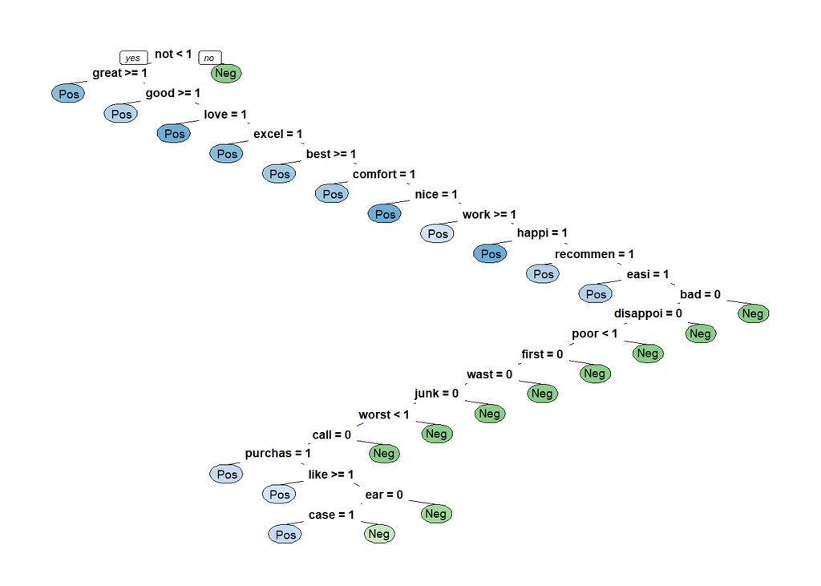

Yes, indeed it does and rather predominantly!

### B. Retrieving Information Included in Negative Short Forms

#### 1. Adding Negative Short Forms to the Bag of Words

First, negative short forms will be introduced into the bag of words and impact on accuracy will be tested.

|  | ACCURACY ON THE TRAINING SET |
| --- | --- |
| Model: Negation + Neg Short Forms + CART + Tuning | 0.8083832 |

Adding negative short forms such as “isn’t” does not impact accuracy level. Consequently, another try will be done about negative short forms: instead of being added, negative short forms will be replaced with “not”.

#### 2. Replacing Negative Short Forms with “not”

|  | ACCURACY ON THE TRAINING SET |
| --- | --- |
| Model: Negation + Neg Short Forms = “not” + CART + Tuning | 0.8038922 |

Replacing negative short forms with “not” downgrades accuracy. This path will not be followed; problematic will be pursued in next section.

### C. Polarization - Text Classsification - Text Substitution

In samples of false negatives and false positives, analysis has pinpointed unigrams and multigrams that convey subjective information.

In the line of these insights, these n-grams have been listed and classified as positive and negative. They have been stopped in four files and uploaded in the GitHub repository https://github.com/Dev-P-L/Sentiment-Analysis :

- subj_pos_multigrams.csv,
- subj_pos_unigrams.csv,
- subj_neg_multigrams.csv,
- subj_neg_unigrams.csv.

Here are a few examples from each file of polarized n-grams.

Positive sentiment oriented unigrams from subj_pos_unigrams.csv (stemmed): “super”, “awesom”, etc.

Some positive multigrams from the file sub_pos_multigrams.csv (not stemmed): “no trouble”, “5 stars”, “thumbs up”, “it’s a ten”, “as described”, “know what they’re doing”.

Possible variants have usually been added, including variants originating from spelling errors or “alternative” grammar: “no troubles”, “not any trouble”, “not any troubles”, “no problem”, “no problems”, etc.; “five stars”, “five star”, “5-star”, “5star”, 5 star“;”must have“;”it’s a 10“,”it’s a ten“,”its a 10“, etc.;”know what theyre doing“,”know what they are doing“, etc.

Some negative unigrams (after stemming) from the file subj_neg_unigrams.csv: “horribl”, “crap”, “whine”, etc.

Some negative multigrams (not stemmed) from the file sub_neg_multigrams.csv: “1 star”, “one star”, “not good”, “no good”, “shouldn’t” (often associated with negative context), “pretty piece of junk”, etc.

Efficacy-minded rules will be applied in NLP.

First, the polarized n-grams will be preceded and followed by one white space character when looking for occurrences in reviews. Otherwise, in the bag of words, the n-gram “most inconvi” would become “most in subjpo” (because “convi” is a polarized unigram in subj_pos_unigrams.csv) and then " subjpo " (because “most” and “in” are stopwords in stopwords_without_apostrophe.csv)! A negatively oriented multigram would become a positively oriented unigram! Consequently, one white space character is added in front of and at the end of each polarized n-gram before looking for matching occurrences in NLP-transformed reviews, in order to avoid replacing substrings.

Second, as a consequence, a white space character has to be added at the beginning and at the end of each NLP-transformed review! Otherwise, polarized n-grams, which are preceded and followed by one white space character can never match an occurrence that is positioned at the beginning or at the end of a review.

Third, as already indicated, " subpos " and “subjneg” contain one white space character at the beginning and at the end, in order to prevent amalgamation. Indeed, what would happen if white space characters were not added? Let’s take our well known example of " conveni “: if it were replaced with just”subjpo" in the n-gram " most conveni “, then it would produce” mostsubjpo“, which would no longer be a generic positive unigram! Transformation would be useless if not annoyingly counterproductive!

Fourth, multiple inter word white space characters have to be reduced to a single inter word white space character: indeed two multigrams differing only in the number(s) of inter word white space characters are treated as different multigrams.

Fifth, in reviews, matching negative n-grams have got to be replaced before matching positive ones. Let’s take the example of " poor fit “, which is a negatively polarized multigram in the file subj_neg_multigrams.csv: if matching with occurrences in reviews begins with positively polarized n-grams, then” poor fit " becomes " poor subjpo “, with” poor " possibly not counterbalancing " subpos " if it is not in a node of the decision tree (or if it is at too low a level).

Sixth, among positive or negative polarized multigrams, they should be tentatively matched in decreasing order in for loops. Why? Let’s take an example of " no good bargain " in one review. In sub_neg_multigrams.csv, there are two negatively polarized multigrams: " no good bargain " and " no good“; if these are considered in decreasing order, then, in the review,” no good bargain " is replaced with " subjneg “, which looks good; otherwise”no good bargain " is replaced with " subjneg bargain " and then " subjneg subjpo “: consequently, instead of having one negative generic unigram we would get one positive and one negative generic unigrams!

NLP will be rerun again. In each training review, all n-grams that match positive n-grams from subj_pos_multigrams.csv or subj_pos_unigrams.csv will be replaced with a generic positive token (“subjpo”); all n-grams that match negative n-grams from subj_neg_multigrams.csv or subj_neg_unigrams.csv will be replaced with a generic negative token (“subjneg”).

The utf8 package will be used to normalize punctuation: there has been some trouble with curly apostrophes instead of straight apostrophes.

|  | ACCURACY ON THE TRAINING SET |
| --- | --- |
| Model: Negation + Polarization + CART + Tuning | 0.9176647 |

Polarizing n-grams that convey subjective information has dramatically boosted accuracy from 81 % to 92 %. Nevertheless, let us stay realistic: text mining has been performed on the training set and is not necessarily, or at least not necessarily entirely, transposable to the validation set.

To get some visual representation of changes, let’s have a look at the wordcloud.

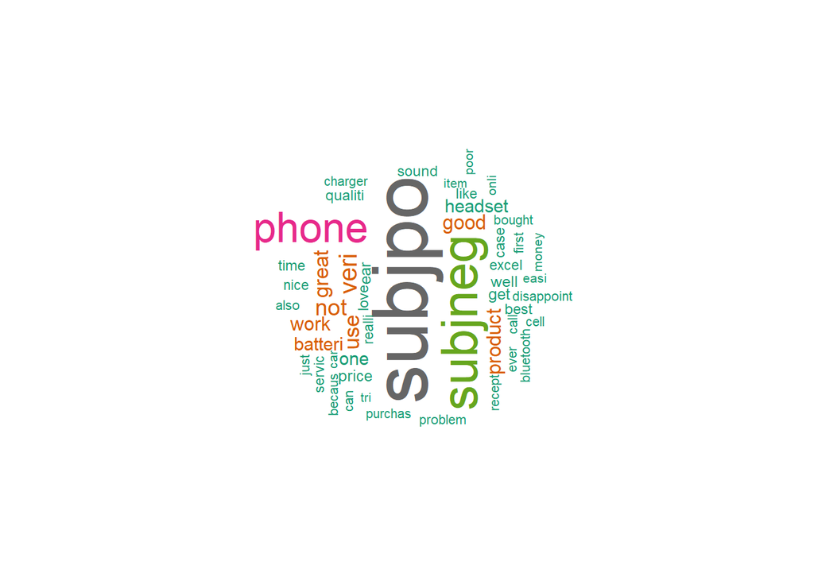

The whole picture has changed. The most frequent tokens are now “subjpo” and “subjneg”. “not” is present, at the “fourth level” (graphically).

The following histogram adds some quantitative insight.

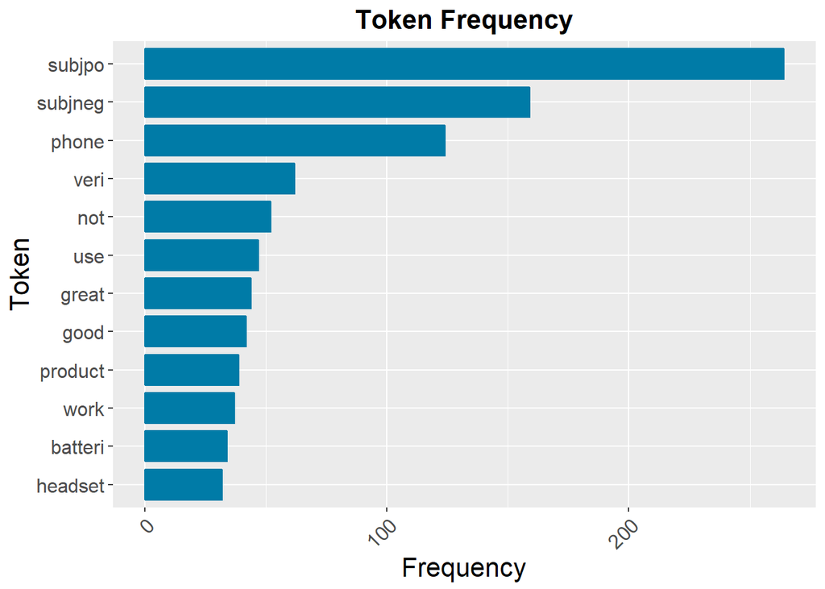

Is there any parallel evolution in the decision tree?

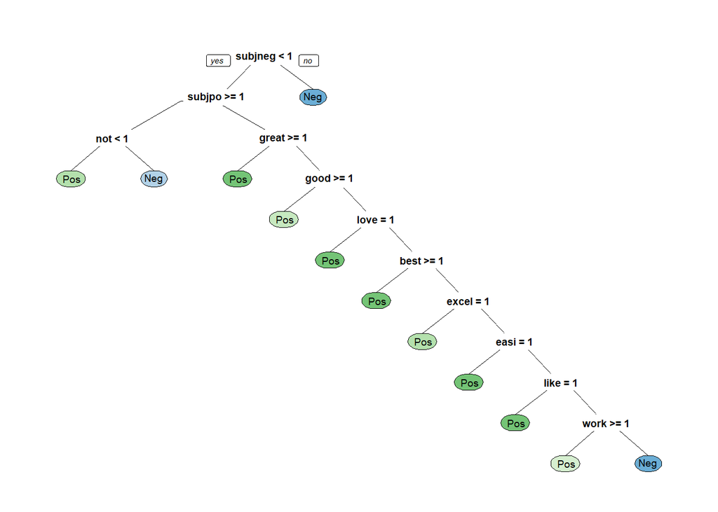

Yes, indeed there is now more parallelism between wordcloud/histogram and decision tree! The most frequent tokens in the wordcloud are now at the top of the decision tree. Indeed, the first node is occupied by “subjneg”; then comes “subjpo” and at the same level “not” and “great”. Many individual tokens that were previously in nodes of the tree, have disappeared.

The next table summarizes accuracy results obtained so far.

| MODEL ID | SHORT DESCRIPTION | ACCURACY | SENSITIVITY | NEG PRED VAL | SPECIFICITY | POS PRED VAL |
| --- | --- | --- | --- | --- | --- | --- |
| baseline | baseline model | 0.5000 | 1.0000 | Div. by 0 | 0.0000 | 0.5000 |
| cart_av0 | CART | 0.7784 | 0.6617 | 0.7257 | 0.8952 | 0.8633 |
| cart_tuned_av0 | CART + tuning | 0.7859 | 0.7126 | 0.7493 | 0.8593 | 0.8351 |
| cart_tuned_av1_a | CART + tuning + negation | 0.8084 | 0.7156 | 0.7601 | 0.9012 | 0.8787 |
| cart_tuned_av1_b | CART + tuning + negation + neg short forms | 0.8084 | 0.7156 | 0.7601 | 0.9012 | 0.8787 |
| cart_tuned_av1_c | CART + tuning + negation + neg short forms = “not” | 0.8039 | 0.6497 | 0.7323 | 0.9581 | 0.9394 |
| cart_tuned_av2 | CART + tuning + negation + polarization | 0.9177 | 0.8862 | 0.893 | 0.9491 | 0.9457 |

As shown in the last two rows, thanks to polarization, accuracy has jumped from 81 % up to 92 %, which is impressive.

Let’s have a look at the numbers of remaining false negatives and positives in the following confusion matrix.

|  | Actually positive | Actually negative |
| --- | --- | --- |
| Predicted positive AFTER POLARIZING | 296 | 17 |
| Predicted negative AFTER POLARIZING | 38 | 317 |

After improving accuracy thanks to NLP and text mining, new accuracy improvements will be looked for in the next section through machine learning, diversifying models.

## IV. MACHINE LEARNING SEARCH FOR ACCURACY ON THE TRAINING SET

Ten models are going to be applied.

### A. 10 Machine Learning Models

Ten machine learning models have been chosen. Here is the list, with an identifier and a short description for each model.

| MODEL ID | MODEL | NAME IN CARET | # TUNING VALUES | # BOOTSTRAPPED RESAMPLES |
| --- | --- | --- | --- | --- |
| adaboost_03 | AdaBoost Classification Trees | adaboost | 3 | 25 |
| cart_03 | CART | rpart | 3 | 25 |
| gbm_03 | Stochastic Gradient Boosting | gbm | 3 | 25 |
| monmlp_03 | Monotone Multi-Layer Perceptron Neural Network | monmlp | 3 | 25 |
| rf_03 | Random Forest | rf | 3 | 25 |
| svm_03 | Support Vector Machines with Radial Basis Function Kernel | svmRadialCost | 3 | 25 |
| xgb_03 | eXtreme Gradient Boosting | xgbLinear | 3 | 25 |
| cart_15 | CART | rpart | 15 | 25 |
| gbm_15 | Stochastic Gradient Boosting | gbm | 15 | 25 |
| svm_15 | Support Vector Machines with Radial Basis Function Kernel | svmRadialCost | 15 | 25 |

All models will be trained with the train() function from the package caret.

For four models, by default, training is done on 25 bootstrapped resamples and on 3 values of the parameters tuned. These models are “adaboost”, “rf”, “xgb” and “monmlp”. For three models that run faster on my PC, two options have been applied: either default training or training with tuning on 15 values across parameters tuned.

The names of the parameters tuned by the train() function are available in http://topepo.github.io/caret/available-models.html.

### B. Accuracy Results on the Training Set

The accuracy results are summarized in the next table.

| MODEL ID | MODEL | # TUNING VALUES | # BOOTSTRAPPED RESAMPLES | ACCURACY ON THE TRAINING SET |
| --- | --- | --- | --- | --- |
| rf_03 | Random Forest | 3 | 25 | 0.9850 |
| adaboost_03 | AdaBoost Classification Trees | 3 | 25 | 0.9820 |
| monmlp_03 | Monotone Multi-Layer Perceptron Neural Network | 3 | 25 | 0.9820 |
| svm_15 | Support Vector Machines with Radial Basis Function Kernel | 15 | 25 | 0.9790 |
| svm_03 | Support Vector Machines with Radial Basis Function Kernel | 3 | 25 | 0.9760 |
| xgb_03 | eXtreme Gradient Boosting | 3 | 25 | 0.9461 |
| gbm_15 | Stochastic Gradient Boosting | 15 | 25 | 0.9371 |
| gbm_03 | Stochastic Gradient Boosting | 3 | 25 | 0.9237 |
| cart_15 | CART | 15 | 25 | 0.9177 |
| cart_03 | CART | 3 | 25 | 0.7754 |

Not surprisingly, most models seem to overfit. As pointed out in literature, it is a rather widespread tendency, the more so with complex algorithms which have many parameters they can minimize the loss function on.

Moreover, NLP and text mining have been extensively adjusted on the training set.

Consequently, the ranking figuring in the table above is no appropriate tool to separate models.

Accuracy cannot be tested on the validation set since the validation set is only to be used as a last step; if some testing is performed on the validation set, it is no longer a validation set.

Moreover, the whole sample being very limited (1,000 reviews), it was probably potentially counter-productive to divide it into training, test and validation sets.

### C. Testing on Bootstrap Resample Accuracy Distributions

But there are some unused resources. The train() function from caret has automatically trained the models on 25 bootstrapped resamples, for all values of the tuned parameters, i.e. on three values of the tuned parameters except where extra tuning on 15 values had been asked, i.e. CART, svm and gbm (chosen because running time was limited). Actually, there is tuning on all models but in three cases there is extra tuning.

For each of the 10 models, accuracy is available for each of the 25 resamples: for each model and for each resample it is accuracy with the parameter optimizing value(s), i.e. the value(s) that deliver(s) the highest accuracy level on average on all the 25 resamples.

This produces for each model a distribution of accuracy, i.e. a set of 25 accuracy levels corresponding to the optimizing parameter value(s).

Each resample is a sample of the training set with replacement. It has the same number of rows as the training set. That is why the bootstrapping method has been preferred to e.g. the K-fold cross-validation, which would have implied further splitting of an already small dataset.

For each model, the bootstrapped accuracy distribution can deliver precious indications: what’s the average, the median, the maximum? It can tell about the generalizability of the accuracy levels computed.

First, accuracy distributions will be extracted for the 10 models. Ten graphs will be drawn with the resample accuracy distribution from the ten models.

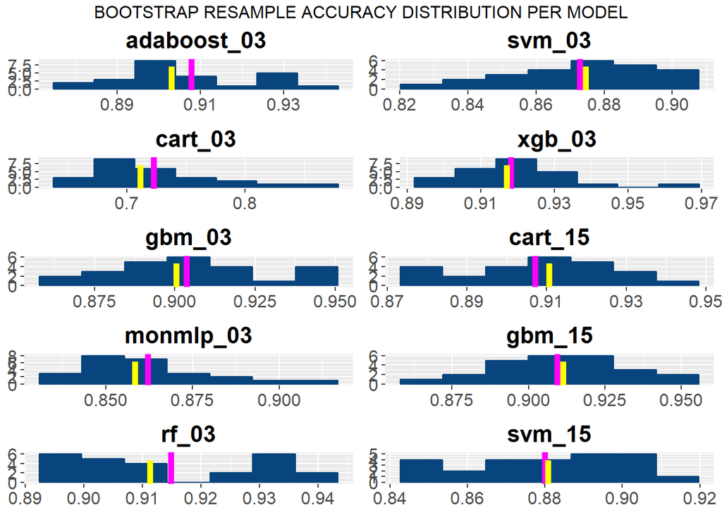

On these graphs, the mean appears as a vertical magenta line and the median as a vertical dashed yellow line.

What’s new in comparison with information delivered by predicting on the whole training set?

To evaluate the merits of the remaining models, let’s produce a comparative table.

| ID | Min. | 1st Qu. | Median | Mean | 3rd Qu. | Max. |
| --- | --- | --- | --- | --- | --- | --- |
| xgb_03 | 0.8943 | 0.9061 | 0.9170 | 0.9182 | 0.9295 | 0.9608 |
| rf_03 | 0.8943 | 0.9000 | 0.9113 | 0.9148 | 0.9309 | 0.9380 |
| adaboost_03 | 0.8794 | 0.8984 | 0.9031 | 0.9078 | 0.9227 | 0.9380 |
| cart_15 | 0.8735 | 0.8953 | 0.9106 | 0.9071 | 0.9183 | 0.9378 |
| gbm_15 | 0.8653 | 0.8984 | 0.9113 | 0.9093 | 0.9227 | 0.9490 |
| gbm_03 | 0.8653 | 0.8889 | 0.9004 | 0.9037 | 0.9142 | 0.9451 |
| svm_15 | 0.8434 | 0.8661 | 0.8809 | 0.8799 | 0.8963 | 0.9095 |
| monmlp_03 | 0.8313 | 0.8500 | 0.8584 | 0.8620 | 0.8723 | 0.9052 |
| svm_03 | 0.8273 | 0.8584 | 0.8745 | 0.8727 | 0.8902 | 0.9024 |
| cart_03 | 0.6426 | 0.6870 | 0.7114 | 0.7227 | 0.7617 | 0.8494 |

The top model is xgb.

For the record, cart-tuned doesn’t score badly: it is rather close to gbm_tuned in minimum; it had been used as a practical yardstick in the NLP and text mining part, running relatively quickly and delivering precise information about decision trees.

For the record again, cart-tuned delivers the same accuracy level as when the bag of word was established separately for the train set as in the NLP and text mining sections, to avoid the slightest risk of cross-influence of word frequencies. In this machine learning section, to have the same number of columns, a common bag of words has been developed before splitting into the training set and the validation set: this has exercised no influence on the training set accuracy produced by cart_tuned.

## V. VALIDATION ON THE VALIDATION SET

### A. Constructing the Validation Set

In order to predict on the validation set, the training set and the validation set have to contain the same columns, i.e. same labels (dependent variable) and the same predictors.

The training set already exists, it is sentSparse_av2, which has been built up through NLP and with text mining insights (negational unigrams integrated and generic tokens replacing sentiment polarized tokens). The training set cannot be changed to match the validation set since this would imply, in one way or another, retrieving some information from the validation and instilling it into the training set, which is contrary with the very status of a validation set.

The validation will be constructed in the same way as the training set, but independently: NLP, negational unigrams and polarization. Columns that are in the validation set but not in the training will be removed. Columns that are in the training set but not in the validation set will be added to the validation set as null vectors.

### B. Predicting on the Validation Set

The xgb model can now be validated on the validation set: predictions will be computed on the validation set and then accuracy.

|  | ACCURACY ON THE VALIDATION SET |
| --- | --- |
| Baseline Model | 0.5000 |
| Final Model: NLP + Text Mining + XGBoost + Default Tuning | 0.8795 |

### C. Attributing Accuracy Improvement per Methodological Layer

On the validation set, the baseline delivers an accuracy level of 50 % (just as on the training set). On the validation set again, the final model provides accuracy of 88 %, which is substantially higher.

Where does the improvement come from? From wich step in the whole process: NLP, text mining or machine learning? Splitting contribution to results needs to be done on the validation set since results on the training set can be boosted by overfitting. To evaluate input from each layer, a simple approach will we followed.

On the validation set without polarization and without negation, prediction will be conducted and accuracy produced. The method will be CART with 15-value tuning and 25 bootstrapped resamples: this model is rather fast and can be considered as appropriate without being “machine learning optimization”. This will help evaluate the impact of NLP.

Then, on the validation set with negation, a second evaluation will be conducted: this will help evaluate the impact of integrating negation.

On the validation set with negation and polarization, a third evaluation will be conducted: this will help evaluate the impact of polarization.

The accuracy difference between this last result and the result from eXtreme Gradient Boosting will measure the impact of machine learning optimization.

| METHODOLOGY | ACCURACY ON THE VALIDATION SET |
| --- | --- |
| Baseline Model | 0.5000 |
| NLP + CART + Extra Tuning | 0.7169 |
| NLP + Negation + CART + Extra Tuning | 0.741 |
| NLP + Negation + Polarization + CART + Extra Tuning | 0.8434 |
| NLP + Negation + Polarization + XGBoost + Default Tuning | 0.8795 |

## VI. SUMMARY & CONCLUSION

Through NLP, words have been standardized, sentences (reviews) have been tokenized into stemmed tokens, tokens have been assembled into an actionable Document Term Matrix linking reviews, tokens and labels, i.e. true sentiment orientations of reviews. At the end of this process, prediction gave 79 % accuracy on the training set with a tuned CART model, against only 50 % with a baseline model ignoring NLP.

Through customized text mining, usable subjective information has been retrieved. Comparing token frequency and decision trees has given one insight: the importance of words conveying subjective information. Perusing random samples of false negatives and false positives has produced two insights: first, in many false negatives and false positives, there is clear subjective information available but that does not show in decision trees; second, sentiment polarity of reviews is inverted by negation in a non negligible number of false negatives and false positives. The second insight has led to integrating negation unigrams such as “not”. The first insight has conducted to establishing customized lists of positively oriented tokens and negatively oriented tokens and to replacing them in all reviews with a generic positive token or a generic negative token.

Performance boosting has then been sought through machine learning, comparing accuracy performance from 10 machine learning models.

Instead of using existing dictionaries about sentiment orientation, customized lists have been built. Replacing tokens with two generic tokens according to sentiment polarity has provided an accuracy improvement with 10 percentage points on the validation set. This improvement has shown resilience since it has hardly shrunk from the training set, where it was 11 percentage points, to the 10 percentage points on the vlaidation set, although list building has been operated exclusively on the training set.

## VII. REFERENCES

Availability has been checked up on March 30, 2020.

### A. Sentiment Analysis

https://www.edx.org/course/the-analytics-edge

https://www.tidytextmining.com/sentiment.html

https://medium.com/@annabiancajones/sentiment-analysis-of-reviews-text-pre-processing-6359343784fb

https://cran.r-project.org/web/packages/SentimentAnalysis/vignettes/SentimentAnalysis.html

https://monkeylearn.com/sentiment-analysis/

https://towardsdatascience.com/basic-binary-sentiment-analysis-using-nltk-c94ba17ae386

https://medium.com/@datamonsters/sentiment-analysis-tools-overview-part-1-positive-and-negative-words-databases-ae35431a470c

### B. Text Mining

https://www.tidytextmining.com/tidytext.html

https://monkeylearn.com/text-mining/

### C. About Resample Distribution of Accuracy

https://books.google.be/books?id=GgmqDwAAQBAJ&pg=PA80&lpg=PA80&dq=in+train()+evaluating+accuracy+standard+error+with+results$accuracy+or+with+resample$accuracy

https://www.edx.org/course/data-science-machine-learning

## D. Something Simple about Overfitting

https://www.r-bloggers.com/machine-learning-explained-overfitting/

# *********************************************************************************

# *********************************************************************************